# NB_visualize

```python
import matplotlib.pyplot as plt

from analysis.visualize.utils_contactmap import plot_contactmap, plot_diffmap, plot_contactmap_w_arcbands
```

### Plotting Contactmaps

Using these functions, contact maps can be constructed from the pairs files to visualize your transcripts/isoforms of interest. First, we visualize the differences among the following methods (KARR-seq, PARIS and RIC-seq) by looking at the Telomerase RNA component, TERC, transcript. By proving a dot-bracket notation file, we can overlap secondary structures onto the contact map. Here, we use the known secondary structure obtained from [Rfam](https://rfam.org/family/RF00024) to illustrate.

```
(<Figure size 1296x576 with 6 Axes>, array([[<AxesSubplot:>]], dtype=object))
```

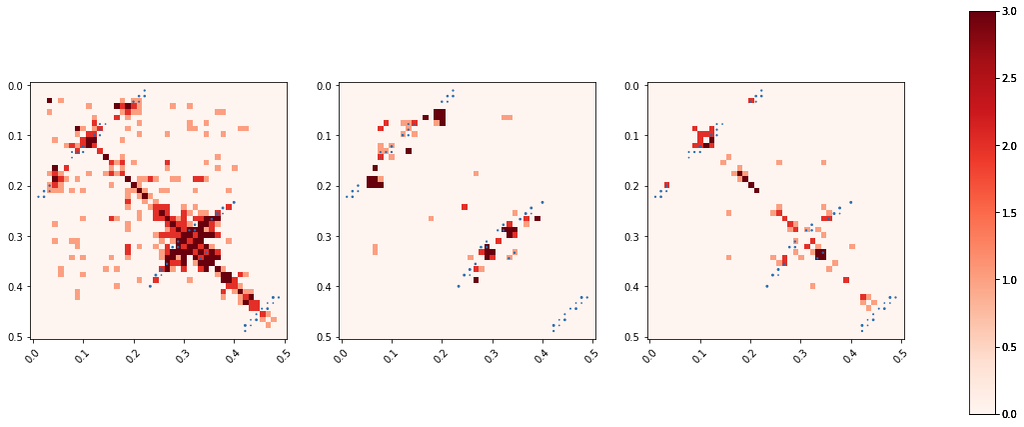

```python
data_KARRseq = ["data/inner/hrefseq/MAPQ1_SPAN0/G1_kethoxal-HEK293T_M13_B01.dedup.pairs.gz"]
data_PARIS = ["data/inner/hrefseq/MAPQ1_SPAN0/PARIS-HEK293T_B97_B01.nodedup.pairs.gz"]
data_RIC = ["data/inner/hrefseq/MAPQ1_SPAN0/RIC-HeLa-rRNA-_M94_B01.dedup.pairs.gz"]

fig, ax = plt.subplots(1, 3, figsize=(18, 8))

# KARR-seq (Left)
plot_contactmap(data_KARRseq, p_chrom1="NR_001566", p_resolution=10, p_max=3, p_figsize=(6, 6),
                p_structure=False, p_genome="hg19", p_display="full", p_balance=False,
                p_dot_size=0.5, f_dot="data/sec_struct/TERC.dot",
                f_size="data/reference/hg19/hg19_refseq_wo_version.sizes", p_ax=(fig, ax[0]), p_verbose=False)

# PARIS (Center)
plot_contactmap(data_PARIS, p_chrom1="NR_001566", p_resolution=10, p_max=3, p_figsize=(6, 6),
                p_structure=False, p_genome="hg19", p_display="full", p_balance=False,
                p_dot_size=0.5, f_dot="/mnt/chenga/projects/rnarna/analysis/TechComparison/TERC.dot",
                f_size="data/reference/hg19/hg19_refseq_wo_version.sizes", p_ax=(fig, ax[1]), p_verbose=False)

# RIC-seq (Right)
plot_contactmap(data_RIC, p_chrom1="NR_001566", p_resolution=10, p_max=3, p_figsize=(6, 6),
                p_structure=False, p_genome="hg19", p_display="full", p_balance=False,
                p_dot_size=0.5, f_dot="/mnt/chenga/projects/rnarna/analysis/TechComparison/TERC.dot",
                f_size="data/reference/hg19/hg19_refseq_wo_version.sizes", p_ax=(fig, ax[2]), p_verbose=False)
```

### Clustering chimeric reads and classifying them into loops, left stripes and right stripes

To cluster the chimeric groups, we first define a similarity function by counting the amount of overlapd between two chimeric pairs. We can then construct the graph by building the similarity matrix, and then cluster the chimeric reads into chimeric groups by using a greedy modularity algorithm. We can then classify the chimeric groups into loops, left stripes and right stripes.

```python
from analysis.clustering.cluster_pairs import cluster_chimeric_pairs
data_txt = "data/pairs/hrefseq/MAPQ1_SPAN0/G1_kethoxal-HepG2-refold_M13_R01.txt.gz"

dict_kwargs = {
    "p_iid": "NM_001404", "p_genome": None,
    "p_long": 200, "p_span": 10, "p_overlap": 10, "p_min_reads": 3,
    "p_min_interactions": 200, "p_max_interactions": 20000,
    "f_sizes": None, "f_tsne": None, "f_pairs": data_txt, "f_output": None, "f_bed": None
}
results = cluster_chimeric_pairs(**dict_kwargs)
```

```
NM_001404 None 200 10 10 3 200 20000 None None /mnt/chenga/projects/rnarna/data/star/pairs/se/hrefseq/MAPQ1_SPAN0/G1_kethoxal-HepG2-refold_M13_R01.txt.gz None None
13
[['NM_001404', 471, 540, 'NM_001404', 823, 890], ['NM_001404', 816, 898, 'NM_001404', 986, 1074], ['NM_001404', 275, 336, 'NM_001404', 478, 566], ['NM_001404', 1198, 1287, 'NM_001404', 1365, 1467], ['NM_001404', 458, 541, 'NM_001404', 1367, 1444], ['NM_001404', 926, 998, 'NM_001404', 1401, 1470], ['…
```

### Plotting Contactmaps with ArcBands

```
(<Figure size 720x720 with 3 Axes>, array([[<AxesSubplot:>]], dtype=object))
```

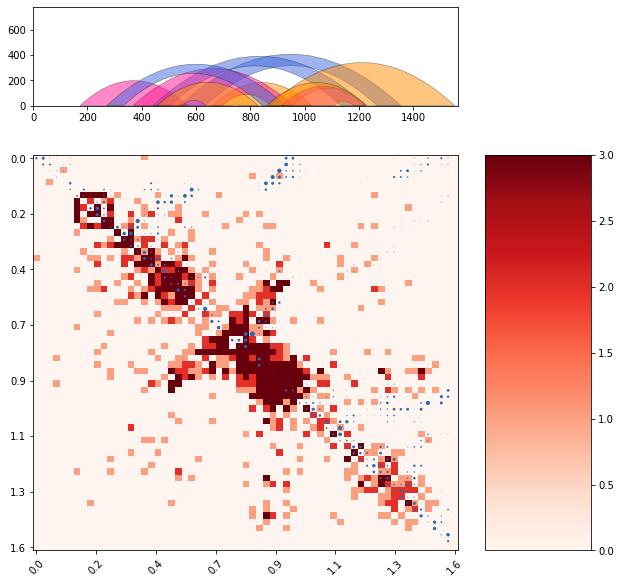

```python
data_mouse = ["data/pairs/mrefseq/MAPQ1_SPAN0/G1_kethoxal-mESC-refold_M13_R01.dedup.pairs.gz",
              "data/pairs/mrefseq/MAPQ1_SPAN0/G1_kethoxal-mESC-refold_M13_R02.dedup.pairs.gz"]

f_cluster_mouse = "data/clustering/output/mrefseq/G1_kethoxal-mESC-refold_M13_C01.dedup.classification.txt"

plot_contactmap_w_arcbands(data_mouse, f_cluster_mouse, p_chrom1="NM_026007.4", p_resolution=25, p_max=3, p_figsize=(10, 10),
                           p_structure=True, p_genome=None, p_display="upper", p_balance=False,
                           f_fasta = "data/reference/mm10/mm10_refseq.fa",
                           f_size = "data/reference/mm10/mm10_refseq.sizes",
                           p_dot_size=1.0, p_multi=False, p_verbose=False)
```

... and then for human EEF1G

```
(<Figure size 720x720 with 3 Axes>, array([[<AxesSubplot:>]], dtype=object))
```

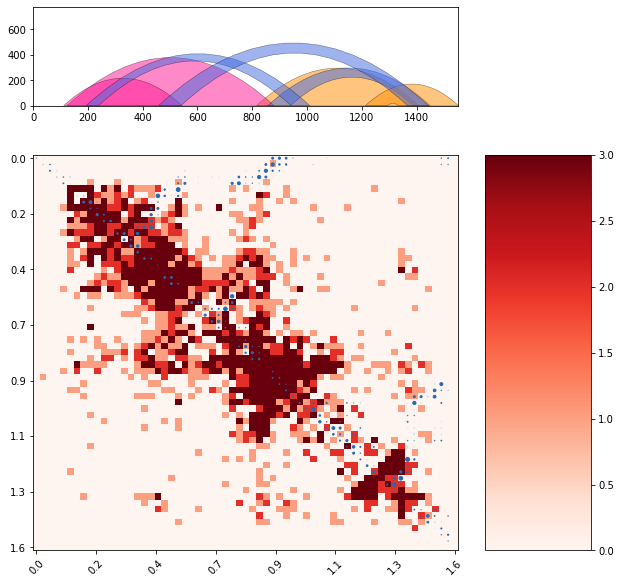

```python
data_human = ["data/pairs/hrefseq/MAPQ1_SPAN0/G1_kethoxal-HepG2-refold_M13_R01.dedup.pairs.gz",
              "data/pairs/hrefseq/MAPQ1_SPAN0/G1_kethoxal-HepG2-refold_M13_R02.dedup.pairs.gz"]
f_cluster_human = "data/clustering/output/hrefseq/G1_kethoxal-HepG2-refold_M13_C01.dedup.classification.txt"

plot_contactmap_w_arcbands(data_human, f_cluster_human, p_chrom1="NM_001404", p_resolution=25, p_max=3, p_figsize=(10, 10),
                           p_structure=True, p_genome="hg19", p_display="upper", p_balance=False,
                           f_fasta = "data/reference/hg19/hg19_refseq_wo_version.fasta",
                           f_size = "data/reference/hg19/hg19_refseq_wo_version.sizes",
                           p_dot_size=1.0, p_multi=False, p_verbose=False)
```

### Differential Maps

To identify the features separating the in-vitro and in-vivo contact maps, we can use the plot_diffmap function.

```
(<Figure size 1296x576 with 4 Axes>, array([[<AxesSubplot:>]], dtype=object))
```

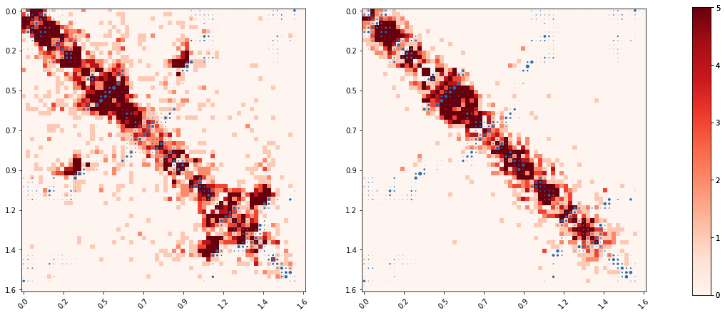

```python
data_vitro = ["data/pairs/hrefseq/MAPQ1_SPAN0/G1_kethoxal-HepG2-refold_M13_R01.dedup.pairs.gz"]
data_vivo = ["data/pairs/hrefseq/MAPQ1_SPAN0/G1_kethoxal-HepG2_M13_R01.dedup.pairs.gz"]

fig, ax = plt.subplots(1, 2, figsize=(18, 8))

plot_contactmap(data_vitro, p_chrom1="NM_001085", p_resolution=25, p_max=5, p_figsize=(6, 6),
             p_structure=True, p_genome="hg19", p_display="full", p_balance=False,
             p_dot_size=1.0,
             f_size="data/reference/hg19/hg19_refseq_wo_version.sizes", p_ax=(fig, ax[0]), p_verbose=False)

plot_contactmap(data_vivo, p_chrom1="NM_001085", p_resolution=25, p_max=5, p_figsize=(6, 6),
             p_structure=True, p_genome="hg19", p_display="full", p_balance=False,
             p_dot_size=1.0,
             f_size="data/reference/hg19/hg19_refseq_wo_version.sizes", p_ax=(fig, ax[1]), p_verbose=False)
```

[output not shown]

```
(<Figure size 800x600 with 2 Axes>, array([[<AxesSubplot:>]], dtype=object))
```

[figure not shown]

```python
data_pairs = ["data/pairs/hrefseq/MAPQ1_SPAN0/G1_kethoxal-HepG2-refold_M13_R01.dedup.pairs.gz",
              "data/pairs/hrefseq/MAPQ1_SPAN0/G1_kethoxal-HepG2_M13_R01.dedup.pairs.gz"]

plot_diffmap(data_pairs, p_chrom1="NM_001085", p_resolution=25, p_max=5, p_figsize=(6, 6),
             p_structure=True, p_genome="hg19", p_display="upper", p_balance=False,
             p_dot_size=1.0, p_diff="norm_diff",
             f_size="data/reference/hg19/hg19_refseq_wo_version.sizes", p_verbose=True)
```